# Data Science Specialization - Practical ML Course Project

The goal of the project is to use data from accelerometers on the belt, forearm, arm, and dumbell of 6 participants in order to predict whether they perform barbell lifts correctly or incorrectly in 5 different ways: A (correct); B, C, D, E (false).

We first import the test and training data by assigning NA values to the empty entries:

```r
training <- read.csv("pml-training.csv",na.strings = c("#DIV/0!","NA"))
testing <- read.csv("pml-testing.csv",na.strings = "#DIV/0!")
```

Summary of the training set reveals several columns with mostly NA values:

```r
summary(training) #not shown to save space
```

We remove those columns from the dataset:

```r
#find columns that have lots of NAs
usefulIndex <- apply(training, 2, function(x) ifelse(sum(is.na(x))>10000, 0 , 1))
usefulIndex <- as.logical(usefulIndex)
#remove NA columns
training <- training[,usefulIndex]
testing <- testing[,usefulIndex]
```

We further remove the first 7 columns that are irrelevant for prediction purposes:

```r
#remove the initial 7 columns which are not informative
training <- training[,-(1:7)]
testing <- testing[,-(1:7)]
```

At this point all our variables are in numeric form which seems appropriate. We apply random forest algorithm considering the number of variables which are mostly correlated.

```r
set.seed(1000)
library(randomForest)
model <- randomForest(classe ~., data = training) #with default parameters
model$confusion
```

```
##      A    B    C    D    E class.error
## A 5578    1    0    0    1   0.0003584
## B   12 3780    5    0    0   0.0044772
## C    0   12 3409    1    0   0.0037989
## D    0    0   22 3191    3   0.0077736
## E    0    0    1    4 3602   0.0013862
```

Notice that cross-validation is not necessary with random forests as long as we are not performing feature selection. The error rates obtained are quite low. Actually, rates were low even with 80-90 trees in the forest:

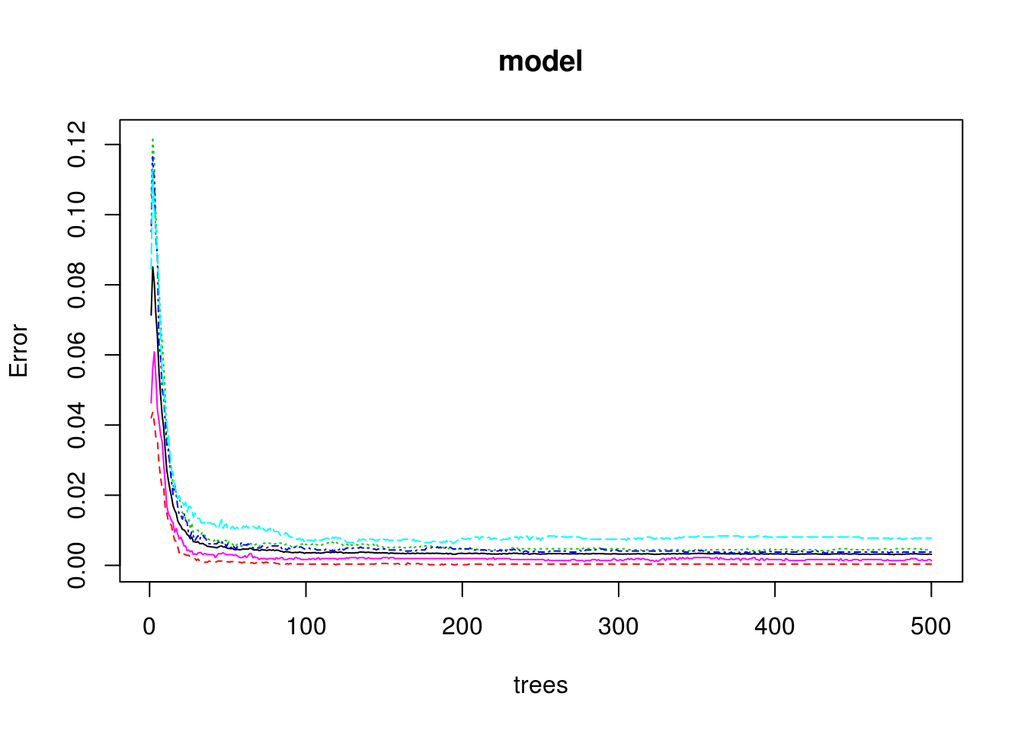

```r
plot(model)
```

The OOB estimate for the model is:

```r
model$err.rate[500,1]
```

```
##     OOB
## 0.00316
```